# R Notebook

```r
library(corrplot)
dfo=read.csv('D:\\bl\\insight-test.csv')
```

```r
df=data.frame(dfo)
```

From the EDA in Python Jupyter Notebook we see that voucher_valid has NAN value, while trx_is_voucher has no NA value.

| index | has nan? | dtypes | num of unique values | list of unique values |
| --- | --- | --- | --- | --- |
| user_id | false | int64 | 69306 | [281605921 125302602 125327377 … 121187821 124128885 124611908] |
| is_new | false | int64 | 2 | [1 0] |
| time | false | object | 229835 | [‘2015-06-12 03:41:44.263000+00:00’ ’2015-06-15 |
| voucher_type | true | float64 | 2 | [nan 1. 0.] |
| voucher_valid | true | float64 | 2 | [nan 1. 0.] |
| basket_amount | false | float64 | 125094 | [2.87720076e-05 2.35151605e-05 1.64053187e-04 … 7.68194141e-06 1.74740762e-04 6.00342486e-05] |
| voucher_max_amount | false | float64 | 26 | [0.0e+00 2.0e-04 4.0e-04 1.0e-03 |
| voucher_percentage | false | float64 | 20 | [ 0. 1. 2. 1.5 10. 20. 99. 50. 15. 5. 7.5 0.8 0.5 25. 80. 0.7 3. 4. 12. 0.6] |
| voucher_min_purchase | false | float64 | 16 | [0.0e+00 1.0e-02 2.0e-02 6.0e-03 2.0e-03 4.0e-03 1.0e-03 1.0e+00 2.0e-01 4.0e-02 3.0e-03 1.0e-05 1.0e-01 2.0e-05 4.0e-04 1.2e-03] |
| voucher_amount | false | float64 | 7451 | [0. 0.01986362 0.01932352 … 0.01088298 0.03666067 0.01636898] |
| trx_is_voucher | false | int64 | 2 | [0 1] |
| is_paid | false | int64 | 2 | [0 1] |
| is_remitted | false | int64 | 2 | [0 1] |
| user_purchased_prior | false | int64 | 2 | [0 1] |
| num_voucher_errors | false | int64 | 102 | [ 0 6 5 1 3 16 48 23 4 24 22 20 19 18 7 15 17 14 |
| purchase | false | int64 | 2 | [0 1] |
| province | false | int64 | 27 | [ 0 1 2 3 4 5 6 7 8 9 10 11 12 13 14 15 16 17 18 19 20 21 22 23 24 25 26] |
| marketing_tier | true | object | 4 | [‘tier_2’ ‘tier_1’ ‘tier_3’ ‘tier_4’ nan] |
| user_type | false | int64 | 16 | [ 0 1 2 3 4 5 6 7 8 9 10 11 12 13 14 15] |
| user_group | false | int64 | 2 | [0 1] |
| account_type | false | int64 | 7 | [0 1 2 3 4 5 6] |
| referrer_type | false | int64 | 7 | [0 1 2 3 4 5 6] |
| account_created_at | false | object | 69159 | [‘2014-03-23 04:01:30+00:00’ ‘2013-07-18 07:24:40+00:00’] |
| user_register_from | false | int64 | 8 | [0 1 2 3 4 5 6 7] |
| sessions | false | float64 | 1513 | [0.00415763 0.01644975 0.02440347 … 0.25180766 0.22125813 0.16666667] |
| average_session_length | false | float64 | 72918 | [0.00142015 0.00484802 0.00305943 … 0.00637333 0.02813384 0.00343421] |
| num_visit_promo_page | false | float64 | 95 | [0. 0.00675676 0.02027027 0.04054054 0.10810811 0.01351351 |
| num_product_types | false | float64 | 31 | [0. 0.22580645 0.03225806 0.19354839 0.48387097 0.35483871 |
| num_trx | false | float64 | 1868 | [0.00000000e+00 9.00009000e-05 7.23920283e-05 … 2.32437107e-03 3.29285902e-03 3.86612562e-03] |
| num_trx_voucher | false | float64 | 122 | [0. 0.01616628 0.02309469 0.00923788 0.00230947 0.03926097 ] |
| gmv | false | float64 | 65720 | [0.033242 0.03388193 0.03347649 … 0.03412042 0.03324484 0.03326364] |
| aov | false | float64 | 65714 | [0.15561851 0.15770251 0.15656791 … 0.16049226 0.15576011 0.15594275] |

Let’s make dummies out of voucher valid and see the correlation of NA value

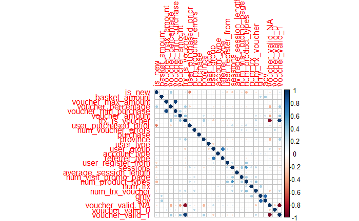

```r
df$voucher_valid_NA = ifelse(is.na(df$voucher_valid),1,0)
df$voucher_valid_0 = ifelse(!is.na(df$voucher_valid) & df$voucher_valid==0,1,0)
df$voucher_valid_1 = ifelse(!is.na(df$voucher_valid) & df$voucher_valid==1,1,0)
num_cols <- unlist(lapply(df, is.numeric))
dfnum=df[ , num_cols]
dfnum=subset(dfnum, select = -c(user_id, is_paid, is_remitted, voucher_type, voucher_valid))
correlations=cor(dfnum)
corrplot(correlations, method="circle")
```

Since voucher_valid is the prequisite of trx_is_voucher, we impute voucher_valid from trx_is_voucher

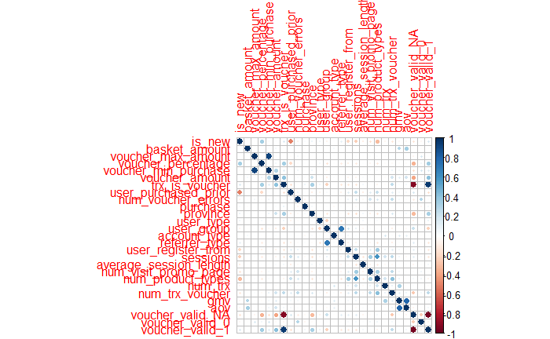

```r
df$voucher_valid =ifelse(is.na(df$voucher_valid), ifelse(df$trx_is_voucher==1, 1, NA), df$voucher_valid)
df$voucher_valid_NA = ifelse(is.na(df$voucher_valid),1,0)
df$voucher_valid_0 = ifelse(!is.na(df$voucher_valid) & df$voucher_valid==0,1,0)
df$voucher_valid_1 = ifelse(!is.na(df$voucher_valid) & df$voucher_valid==1,1,0)
library(corrplot)
num_cols <- unlist(lapply(df, is.numeric))
dfnum=df[ , num_cols]
dfnum=subset(dfnum, select = -c(user_id, is_paid, is_remitted, voucher_type, voucher_valid))
correlations=cor(dfnum)
corrplot(correlations, method="circle")
```

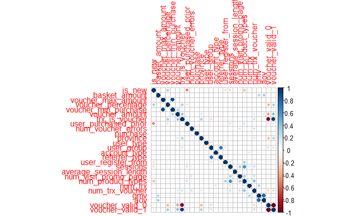

```r
df$voucher_valid =ifelse(is.na(df$voucher_valid), ifelse(df$trx_is_voucher==1, 1, 0), df$voucher_valid)
df$voucher_valid_NA = ifelse(is.na(df$voucher_valid),1,0)
df$voucher_valid_0 = ifelse(!is.na(df$voucher_valid) & df$voucher_valid==0,1,0)
df$voucher_valid_1 = ifelse(!is.na(df$voucher_valid) & df$voucher_valid==1,1,0)
library(corrplot)
num_cols <- unlist(lapply(df, is.numeric))
dfnum=df[ , num_cols]
dfnum=subset(dfnum, select = -c(user_id, is_paid, is_remitted, voucher_type, voucher_valid,voucher_valid_NA))
correlations=cor(dfnum)
corrplot(correlations, method="circle")
```

now let’s see voucher_type

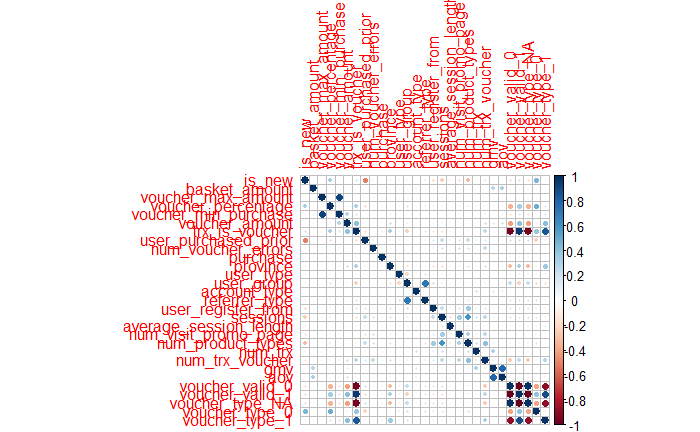

```r
df$voucher_type_NA = ifelse(is.na(df$voucher_type),1,0)
df$voucher_type_0 = ifelse(!is.na(df$voucher_type) & df$voucher_type==0,1,0)
df$voucher_type_1 = ifelse(!is.na(df$voucher_type) & df$voucher_type==1,1,0)

num_cols <- unlist(lapply(df, is.numeric))
dfnum=df[ , num_cols]
dfnum=subset(dfnum, select = -c(user_id, is_paid, is_remitted, voucher_type, voucher_valid,voucher_valid_NA))
correlations=cor(dfnum)
corrplot(correlations, method="circle")
```

Since voucher_type 0 and 1 positively correlated with purchase, while NA correlated negatively, we consider voucher_type==NA as a different category that are not fit to type_0 and type_1.

Let’s look at percentage

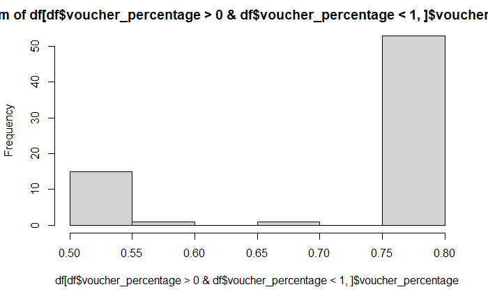

```r
hist(df[df$voucher_percentage>0 &df$voucher_percentage<1,]$voucher_percentage)
```

Percentage has both “0-1 range” & “0-100 range”, looks like anomaly. Let’s multiply the 0-1 with 100

```r
df$voucher_percentage[df$voucher_percentage>0 & df$voucher_percentage<1]=df$voucher_percentage[df$voucher_percentage>0 & df$voucher_percentage<1]*100
```

let’s plot num_trx

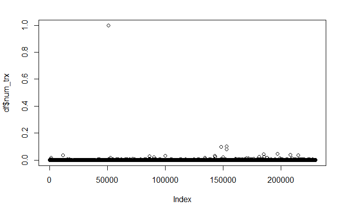

```r
plot(df$num_trx)
```

num_trx==1 is anomaly. let’s exclude num_trx==1

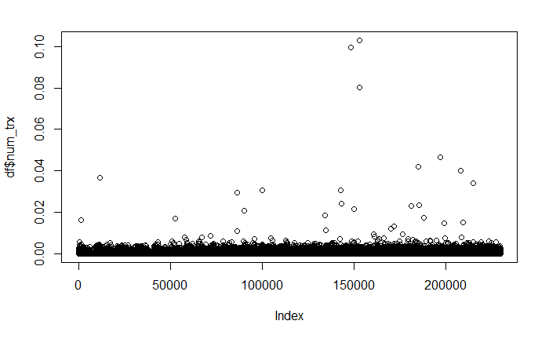

```r
df=df[df$num_trx<1,]
plot(df$num_trx)
```

Now let’s prepare our data for regression analysis

```r
df[is.na(df)] = "NA"
df$province=as.factor(df$province)
df$user_type=as.factor(df$user_type)
df$user_group=as.factor(df$user_group)
df$account_type=as.factor(df$account_type)
df$referrer_type=as.factor(df$referrer_type)
df$user_register_from=as.factor(df$user_register_from)
```

Here I create new feature that measure users’ account age in days

```r
df$time=as.POSIXct(df$time,format="%Y-%m-%d %H:%M:%S")
df$account_created_at=as.POSIXct(df$account_created_at,format="%Y-%m-%d %H:%M:%S")
df$account_day= scale(  ((df$time - df$account_created_at)/86400) )
```

Saya akan melakukan analisis regresi logistik dengan fitur-fitur yang saya pilih.

```r
lm.fit = glm('purchase ~  is_new + account_day + voucher_type + voucher_valid + basket_amount + voucher_max_amount + voucher_percentage + voucher_min_purchase + voucher_amount + trx_is_voucher  + user_purchased_prior + num_voucher_errors + province + marketing_tier + user_type + user_group + account_type + referrer_type + user_register_from + sessions + average_session_length + num_visit_promo_page + num_product_types + num_trx + num_trx_voucher + gmv + aov',data=df, family=binomial)
smry.lm = summary(lm.fit)
smry.lm
```

```
Call:
glm(formula = "purchase ~  is_new + account_day + voucher_type + voucher_valid + basket_amount + voucher_max_amount + voucher_percentage + voucher_min_purchase + voucher_amount + trx_is_voucher  + user_purchased_prior + num_voucher_errors + province + marketing_tier + user_type + user_group + accoun…
    family = binomial, data = df)

Deviance Residuals:
    Min       1Q   Median       3Q      Max
-4.2131   0.1649   0.2431   0.2838   3.0450

Coefficients: (2 not defined because of singularities)
                         Estimate Std. Error z value Pr(>|z|)
(Intercept)             8.601e-01  8.342e+02   0.001 0.999177
is_new                  7.379e-01  5.481e-02  13.462  < 2e-16 ***
account_day             1.050e-01  1.770e-02   5.933 2.97e-09 ***
voucher_type1           9.265e-01  1.448e-01   6.397 1.59e-10 ***
voucher_typeNA          4.079e-01  8.342e+02   0.000 0.999610
voucher_valid          -2.406e+00  8.342e+02  -0.003 0.997698
basket_amount          -1.645e+01  1.164e+01  -1.414 0.157374
voucher_max_amount      2.007e+01  4.885e+00   4.110 3.96e-05 ***
voucher_percentage     -9.857e-03  1.731e-03  -5.693 1.25e-08 ***
voucher_min_purchase   -2.058e+01  4.871e+00  -4.225 2.39e-05 ***
voucher_amount          6.169e-01  9.790e-01   0.630 0.528607
trx_is_voucher          1.866e+01  5.348e+01   0.349 0.727086
user_purchased_prior    4.029e-01  2.768e-02  14.557  < 2e-16 ***
num_voucher_errors     -3.544e-02  2.562e-03 -13.830  < 2e-16 ***
province1               2.154e-01  3.894e-02   5.531 3.19e-08 ***
province2               6.585e-01  5.795e-02  11.363  < 2e-16 ***
province3               2.471e-01  4.806e-02   5.140 2.75e-07 ***
province4               5.202e-01  5.862e-02   8.875  < 2e-16 ***
province5               1.764e-01  8.762e-02   2.013 0.044148 *
province6               4.062e-01  4.233e-01   0.960 0.337236
province7               2.330e-01  7.110e-02   3.277 0.001050 **
province8               5.161e-01  1.057e-01   4.884 1.04e-06 ***
province9               5.013e-01  2.498e-01   2.007 0.044758 *
province10              3.611e-01  1.076e-01   3.356 0.000790 ***
province11              2.660e-01  4.304e-01   0.618 0.536482
province12              1.053e+00  2.581e-01   4.082 4.47e-05 ***
province13              9.756e-01  1.780e-01   5.479 4.27e-08 ***
province14              9.425e-01  2.201e-01   4.282 1.85e-05 ***
province15             -2.331e+00  3.139e-01  -7.425 1.13e-13 ***
province16              2.667e+00  7.161e-01   3.724 0.000196 ***
```

[output cut: 52 more lines]

```
num_product_types       1.012e+00  1.577e-01   6.421 1.36e-10 ***
num_trx                 4.335e+02  4.048e+01  10.708  < 2e-16 ***
num_trx_voucher        -3.498e-01  1.033e+00  -0.338 0.735041
gmv                     6.200e+01  1.618e+01   3.831 0.000127 ***
aov                    -9.692e+00  3.563e+00  -2.720 0.006530 **
---
Signif. codes:  0 ‘***’ 0.001 ‘**’ 0.01 ‘*’ 0.05 ‘.’ 0.1 ‘ ’ 1

(Dispersion parameter for binomial family taken to be 1)

    Null deviance: 65275  on 229845  degrees of freedom
Residual deviance: 58849  on 229761  degrees of freedom
AIC: 59019

Number of Fisher Scoring iterations: 18
```

Berikut koefisien regresi diurutkan berdasarkan besaran absolut dan dipilih hanya yang memiliki p-value<0.001

```r
modcoef <- summary(lm.fit)[["coefficients"]]
dfmod=as.data.frame(modcoef)
#dfmod$exp=exp(dfmod$Estimate)
dfmod=dfmod[order(-abs(dfmod$Estimate)), ]
dfmod[dfmod$`Pr(>|z|)` < 0.001 ,]
```

|  | Estimate | Std. Error | z value | Pr(>\|z\|) |
| --- | --- | --- | --- | --- |
| num_trx | 433.493501979 | 40.482098421 | 10.708276 | 9.307851e-27 |
| gmv | 61.997439163 | 16.182056624 | 3.831246 | 1.274960e-04 |
| voucher_min_purchase | -20.580556025 | 4.871066152 | -4.225062 | 2.388751e-05 |
| voucher_max_amount | 20.073916622 | 4.884510210 | 4.109709 | 3.961577e-05 |
| sessions | -4.336278947 | 0.312526134 | -13.874932 | 8.987791e-44 |
| province17 | 2.791850167 | 0.508848053 | 5.486609 | 4.097233e-08 |
| province16 | 2.666802293 | 0.716056485 | 3.724290 | 1.958654e-04 |
| province15 | -2.330526998 | 0.313871461 | -7.425100 | 1.126947e-13 |
| user_group1 | 2.281896090 | 0.643445217 | 3.546372 | 3.905745e-04 |
| referrer_type1 | -2.200019839 | 0.643917681 | -3.416617 | 6.340450e-04 |

[output cut: 27 more lines]